# Mini-Projet Etude et application de quelques schémas aux différences finies pour deux lois de conservation

AMECK GUY-MAX DESIRE DOSSEH & RIM ELMGHARI

2024-02-05

On souhaite étudier, appliquer et voir le comportement de quelques schémas aux différences finies pour deux équations relevant de lois de conservation 1D définies sur un domaine $\Omega = [0, L]$.

# 1. Equation de transport

On considère l’équation de transport soumise à des conditions aux limites periodiques:

$$(E_{1})\left\{
\begin{array}{ll}
\frac{\partial u}{\partial t} + a\frac{\partial u}{\partial x} = 0,
& \forall x \in ]0,L[\ ; \ \forall t>0 \\
u(x, t=0) = u_0(x), & \forall x \in [0,L] \\
u(0, t) = u(L, t)\ ; \ \frac{\partial u}{\partial x}(L, t)=0 &
\forall t > 0
\end{array}
\right.$$
1) A l’aide de la methode des caracteristiques, determiner la solution exacte $u(x, t)$ du probleme $(E_{1})$.

Nous allons chercher une courbe caractéristique $\Gamma ((t(s), x(s))$, s étant le paramètre qui décrit la courbe, le long de laquelle l’EDP devient un système d’EDO.

$$\begin{aligned}
du &= \frac{\partial u}{\partial t}dt + \frac{\partial u}{\partial
x}dx\\
\frac{du}{ds} &= \frac{\partial u}{\partial t}\frac{dt}{ds} +
\frac{\partial u}{\partial x}\frac{dx}{ds}\\
\frac{du}{ds} &= -a\frac{\partial u}{\partial x}\frac{dt}{ds} +
\frac{\partial u}{\partial x}\frac{dx}{ds}\\
\frac{du}{ds} &= \frac{\partial u}{\partial
x}(\frac{dx}{ds}-a\frac{dt}{ds})
\end{aligned}$$

On voit que si on impose $\frac{dx}{ds}-a\frac{dt}{ds} = 0$, on a $\frac{du}{ds} = 0$, c’est à dire que u est constant le long de la courbe caractéristique.

On a donc le système d’EDO suivant a resoudre:

$$\left\{
\begin{array}{ll}
\frac{dx}{dt} = a \ \text{qui donne la courbe caractéristique }\Gamma\\
du = 0 \ \text{qui donne la solution u(x, t) sur cette courbe
caractéristique}
\end{array}
\right.$$

**Courbes caractéristiques:**

$$\frac{dx}{dt} = a \ \text{donne} \ x(t) = at + \xi (avec \ \xi \
\text{une constante reelle d'integration})$$

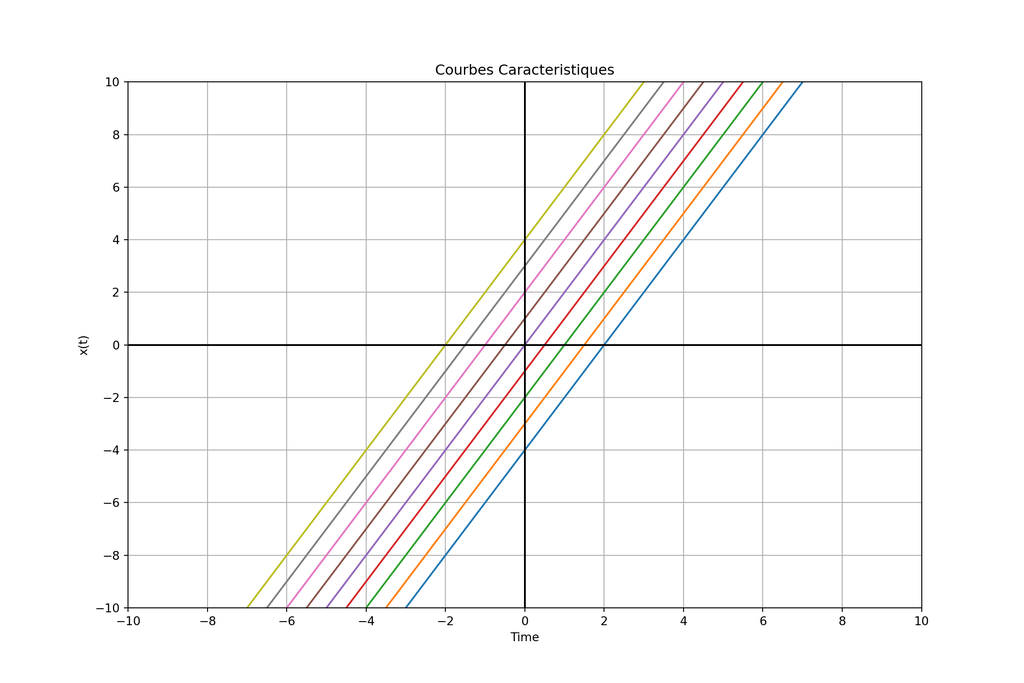

**Solution**

Sur chaque courbe caractéristique $(\Gamma): x-at = \xi$, on a:

$$du = 0 \Rightarrow u(x, t) = cte = f(\xi) \leftarrow i.e. \text{ u ne
depend que de } \xi$$
Soit alors

$$u(x, t) = f(x-at)$$
Cette solution doit etre retrouvee aussi pour $t=0$.

Or a $t=0$, on a:

$$u(x, 0) = u_0(x) = f(x) \Rightarrow f(x) = u_0(x)$$

c’est a dire
$$f\equiv u_0$$

On obtient finalement la solution exacte du probleme $(E_{1})$:

$$u(x, t) = u_0(x-at), \ \forall x \in [0, L], \ \forall t > 0$$

On discretise l’intervalle $[0, L]$ en $(N-1)$ sous-interalles $[x_{i}, x_{i+1}](i=1, ..., N-1)$ de tailles egales $\Delta x(\Delta x=\frac{L}{N-1}, x_{i+1}=x_{i}+\Delta x)$, et on note par $u_{i}^{n}$ la solution approchee au noeud $x_{i}$ a l’instant $t^{n}=n\Delta t$($\Delta t$ etant le pas de chnage).

2. Etudier la consistance, la stabilite et la convergence de chacun des schemas numeriques suivants:

**Schema 1 (centre):**

$$\frac{u_{j}^{n+1}-u_{j}^{n}}{\Delta t} +
a\frac{u_{j+1}^{n}-u_{j-1}^{n}}{2\Delta x} = 0$$

- **Consistance**

Utilisons le développement de Taylor pour évaluer la consistance du schéma. On a:

- D’une part le développement de Taylor de $u_{j}^{n+1}$ à l’ordre 1 :

$$\begin{aligned}
u_{j}^{n+1} &= u_{j}^{n} + \Delta t\frac{\partial u}{\partial
t}|_{j}^{n} + O(\Delta t^2)\\
\frac{\partial u}{\partial t}|_{j}^{n}
&=\frac{u_{j}^{n+1}-u_{j}^{n}}{\Delta t} + O(\Delta t)
\end{aligned}$$

- Et d’autre part le développement de Taylor de $u_{j+1}^{n}$ et $u_{j-1}^{n}$ à l’ordre 2 :

$$\begin{aligned}
u_{j+1}^{n} &= u_{j}^{n} + \Delta x\frac{\partial u}{\partial x} +
\frac{(\Delta x)^2}{2}\frac{\partial^2 u}{\partial x^2} + O((\Delta
x)^3)\\
u_{j-1}^{n} &= u_{j}^{n} - \Delta x\frac{\partial u}{\partial x} +
\frac{(\Delta x)^2}{2}\frac{\partial^2 u}{\partial x^2} + O((\Delta
x)^3)\\
\frac{\partial u}{\partial x}|_{j}^{n}
&=\frac{u_{j+1}^{n}-u_{j-1}^{n}}{2\Delta x} + O((\Delta x)^2)\\
\end{aligned}$$

On obtient alors le schéma numérique:

$$\begin{cases}
\frac{u_{j}^{n+1}-u_{j}^{n}}{\Delta t} +
a\frac{u_{j+1}^{n}-u_{j-1}^{n}}{2\Delta x} = 0 &\ \forall x \in ]0,
L[; \forall t>0 \\
u(x, 0) = u_0(x) &\ \forall x \in [0, L]\\
u(0, t) = u(L, t) \ \text{et} \ \frac{\partial u}{\partial x}(L, t)=0
&\ \forall t > 0
\end{cases}$$

dont l’erreur de troncature est:

$$\begin{aligned}
\text{ET} &= ( \frac{\partial u}{\partial t} + a\frac{\partial
u}{\partial x}) -(\frac{u_{j}^{n+1}-u_{j}^{n}}{\Delta t} +
a\frac{u_{j+1}^{n}-u_{j-1}^{n}}{2\Delta x})\\
&= \mathcal{O}(\Delta t) + \mathcal{O}((\Delta x)^2)\\
\end{aligned}$$

Nous avons donc un schema d’ordre 1 en temps et d’ordre 2 en espace. Par definition de la consistance, Un schéma est dit consistant si l’erreur de troncature tend vers 0 lorsque $\Delta t$ et $\Delta x$ tendent vers 0. Soit:

$$\lim_{\Delta t, \Delta x \to 0} \text{ET} = 0$$

Dans notre cas, on a:

$$\lim_{\Delta t, \Delta x \to 0} \text{ET} = \mathcal{O}(\Delta t) +
\mathcal{O}((\Delta x)^2)$$

Or

$$|\mathcal{O}(\Delta t)| \leq C|\Delta t| \implies \lim_{\Delta t \to 0}
\mathcal{O}(\Delta t) = 0$$
et

$$|\mathcal{O}((\Delta x)^2)| \leq C|\Delta x|^2 \implies \lim_{\Delta x
\to 0} \mathcal{O}((\Delta x)^2) = 0$$

D’où:

$$\lim_{\Delta t, \Delta x \to 0} \text{ET} = 0$$

Par suite, le schéma 1 centre est consistant.

- **Stabilité**

Pour étudier la stabilité du schéma, on utilise la méthode de Von Neumann. On pose:

$$u_{j}^{n} = C^{n}e^{i\xi x_{j}}, \text{ avec } x_j = j\Delta x \text{ et
} \xi \text{ est le nombre d'onde}$$
et on injecte cette solution dans le schéma numérique:

$$\begin{aligned}
\frac{u_{j}^{n+1}-u_{j}^{n}}{\Delta t} +
a\frac{u_{j+1}^{n}-u_{j-1}^{n}}{2\Delta x} = 0 & \implies
\frac{C^{n+1}e^{i\xi x_{j}}-C^{n}e^{i\xi x_{j}}}{\Delta t} +
a\frac{C^{n}e^{i\xi x_{j+1}}-C^{n}e^{i\xi x_{j-1}}}{2\Delta x} = 0\\
& \implies \frac{C^{n+1}e^{i\xi j\Delta x}-C^{n}e^{i\xi
j\Delta x}}{\Delta t} + a\frac{C^{n}e^{i\xi (j+1)\Delta x}-C^{n}e^{i\xi
(j-1)\Delta x}}{2\Delta x} = 0\\
& \implies \frac{C^{n+1}-C^{n}}{\Delta t}e^{i\xi j\Delta x} +
a\frac{e^{i\xi \Delta x}-e^{-i\xi \Delta x}}{2\Delta x}C^{n}e^{i\xi
j\Delta x} = 0\\
& \implies C^{n+1} = C^{n} - \frac{a\Delta t}{\Delta
x}sin(\xi \Delta x)C^{n}\\
& \implies C^{n+1} = (1 - \frac{a\Delta t}{\Delta x}isin(\xi
\Delta x))C^{n}\\
& \implies C^{n+1} = (1 - i\lambda sin(\xi \Delta x))C^{n},
\text{ avec } \lambda = \frac{a\Delta t}{\Delta x}\\
& \implies C^{n+1} = (1 - i\lambda sin(\xi \Delta
x))^{n}C^{0}
\end{aligned}$$

On doit avoir $|1 - i\lambda sin(\xi \Delta x)|\leq 1\ \forall \xi \in \mathbb{R}$

On a:

$$\begin{aligned}
|1 - i\lambda sin(\xi \Delta x)|^2 &\leq 1\\
1+\lambda^2sin^{2}(\xi \Delta x) &\leq 1\\
\lambda^2sin^{2}(\xi \Delta x) &\leq 0 \ (\text{ ce qui est
absurde})\\
\end{aligned}$$

Ainsi, le schéma 1 centre est instable.

- **Convergence**

En utilisant la contraposee du theoreme de Lax, on a:

Le shéma 1 centre n’est pas stable, donc il n’est pas convergent.

**Schema 2 (decentre):**

$$\begin{aligned}
\frac{u_{j}^{n+1}-u_{j}^{n}}{\Delta t} +
a\frac{u_{j}^{n}-u_{j-1}^{n}}{\Delta x} = 0 & \text{ si } a > 0\\
\frac{u_{j}^{n+1}-u_{j}^{n}}{\Delta t} +
a\frac{u_{j+1}^{n}-u_{j}^{n}}{\Delta x} = 0 & \text{ si } a < 0
\end{aligned}$$

- **Cas a > 0**
  - **Consistance**

Utilisons le développement de Taylor pour évaluer la consistance du schéma. On a:

- D’une part le développement de Taylor de $u_{j}^{n+1}$ à l’ordre 1 :

$$\begin{aligned}
u_{j}^{n+1} &= u_{j}^{n} + \Delta t\frac{\partial u}{\partial
t}|_{j}^{n} + O(\Delta t^2)\\
\frac{\partial u}{\partial t}|_{j}^{n}
&=\frac{u_{j}^{n+1}-u_{j}^{n}}{\Delta t} + O(\Delta t)
\end{aligned}$$
+ Et d’autre part le développement de Taylor de $u_{j}^{n}$ et $u_{j-1}^{n}$ à l’ordre 1 :

$$\begin{aligned}
u_{j}^{n} &= u_{j}^{n} + \Delta x\frac{\partial u}{\partial x} +
O(\Delta x^2)\\
u_{j-1}^{n} &= u_{j}^{n} - \Delta x\frac{\partial u}{\partial x} +
O(\Delta x^2)\\
\frac{\partial u}{\partial x}|_{j}^{n}
&=\frac{u_{j}^{n}-u_{j-1}^{n}}{\Delta x} + O(\Delta x)
\end{aligned}$$

On obtient alors le schéma numérique:

$$\begin{cases}
\frac{u_{j}^{n+1}-u_{j}^{n}}{\Delta t} +
a\frac{u_{j}^{n}-u_{j-1}^{n}}{\Delta x} = 0 &\ \forall x \in ]0, L[;
\forall t>0 \\
u(x, 0) = u_0(x) &\ \forall x \in [0, L]\\
u(0, t) = u(L, t) \ \text{et} \ \frac{\partial u}{\partial x}(L, t)=0
&\ \forall t > 0
\end{cases}$$

dont l’erreur de troncature est:

$$\begin{aligned}
\text{ET} &= ( \frac{\partial u}{\partial t} + a\frac{\partial
u}{\partial x}) -(\frac{u_{j}^{n+1}-u_{j}^{n}}{\Delta t} +
a\frac{u_{j}^{n}-u_{j-1}^{n}}{\Delta x})\\
&= \mathcal{O}(\Delta t) + \mathcal{O}(\Delta x)\\
\end{aligned}$$

Nous avons donc un schema d’ordre 1 en temps et d’ordre 1 en espace.

Par definition de la consistance, Un schéma est dit consistant si l’erreur de troncature tend vers 0 lorsque $\Delta t$ et $\Delta x$ tendent vers 0. Soit:

$$\lim_{\Delta t, \Delta x \to 0} \text{ET} = 0$$

Dans notre cas, on a:

$$\lim_{\Delta t, \Delta x \to 0} \text{ET} = \mathcal{O}(\Delta t) +
\mathcal{O}(\Delta x)$$

Or

$$|\mathcal{O}(\Delta t)| \leq C|\Delta t| \implies \lim_{\Delta t \to 0}
\mathcal{O}(\Delta t) = 0$$

et

$$|\mathcal{O}(\Delta x)| \leq C|\Delta x| \implies \lim_{\Delta x \to 0}
\mathcal{O}(\Delta x) = 0$$

D’où:

$$\lim_{\Delta t, \Delta x \to 0} \text{ET} = 0$$

Par suite, le schéma 2 décentré en amont est consistant.

- **Stabilité**

Pour étudier la stabilité du schéma, on utilise la méthode de Von Neumann. On pose:

$$u_{j}^{n} = C^{n}e^{i\xi x_{j}}, \text{ avec } x_j = j\Delta x \text{ et
} \xi \text{ est le nombre d'onde}$$

et on injecte cette solution dans le schéma numérique:

$$\begin{aligned}
\frac{u_{j}^{n+1}-u_{j}^{n}}{\Delta t} +
a\frac{u_{j}^{n}-u_{j-1}^{n}}{\Delta x} = 0 & \implies
\frac{C^{n+1}e^{i\xi x_{j}}-C^{n}e^{i\xi x_{j}}}{\Delta t} +
a\frac{C^{n}e^{i\xi x_{j}}-C^{n}e^{i\xi x_{j-1}}}{\Delta x} = 0\\
& \implies \frac{C^{n+1}e^{i\xi j\Delta x}-C^{n}e^{i\xi
j\Delta x}}{\Delta t} + a\frac{C^{n}e^{i\xi j\Delta x}-C^{n}e^{i\xi
(j-1)\Delta x}}{\Delta x} = 0\\
& \implies \frac{C^{n+1}-C^{n}}{\Delta t}e^{i\xi j\Delta x} +
a\frac{1-e^{-i\xi \Delta x}}{\Delta x}C^{n}e^{i\xi j\Delta x} = 0\\
& \implies C^{n+1} = C^{n} - \frac{a\Delta t}{\Delta
x}(1-e^{-i\xi \Delta x})C^{n}\\
& \implies C^{n+1} = (1 - \frac{a\Delta t}{\Delta
x}(1-e^{-i\xi \Delta x}))C^{n}\\
& \implies C^{n+1} = (1 - \lambda (1-e^{-i\xi \Delta
x}))C^{n}, \text{ avec } \lambda = \frac{a\Delta t}{\Delta x}\\
\end{aligned}$$

On doit avoir $|1 - \lambda (1-e^{-i\xi \Delta x})|\leq 1\ \forall \xi \in \mathbb{R}$

On a:

$$\begin{aligned}
|1 - \lambda (1-e^{-i\xi \Delta x})|^2 &\leq 1\\
|1 - \lambda(1-(cos(-\xi\Delta x)+isin(-\xi\Delta x)))|^2 &\leq 1\\
|1 - \lambda(1-cos(\xi\Delta x)+isin(\xi\Delta x))|^2 &\leq 1\\
|1 - \lambda+\lambda cos(\xi\Delta x)-i\lambda sin(\xi\Delta x))|^2
&\leq 1\\
(1 - \lambda+\lambda cos(\xi\Delta x))^2+(\lambda sin(\xi\Delta x))^2
&\leq 1\\
1 - 2\lambda+\lambda^2 +\lambda^2cos^2(\xi\Delta x)+2(1-\lambda)\lambda
cos(\xi\Delta x)+\lambda^2sin^2(\xi\Delta x) &\leq 1\\
1 - 2\lambda+2\lambda^2 +2(1-\lambda)\lambda cos(\xi\Delta x) &\leq
1\\
2\lambda^2 - 2\lambda+2(1-\lambda)\lambda cos(\xi\Delta x) &\leq 0\\
\lambda^2 - \lambda+(1-\lambda)\lambda cos(\xi\Delta x) &\leq 0\\
\lambda(\lambda-1)-(\lambda-1)\lambda cos(\xi\Delta x) &\leq 0\\
\lambda(\lambda-1)(1- cos(\xi\Delta x)) &\leq 0\\
\end{aligned}$$

Or $\lambda > 0$ et $1-cos(\xi\Delta x) \geq 0$, on doit donc avoir:

$$\begin{aligned}
\lambda - 1 &\leq 0\\
\lambda &\leq 1\\
\lambda=\frac{a\Delta t}{\Delta x} &\leq 1
\end{aligned}$$

Ainsi, le schéma 2 décentré en amont est stable si $\frac{a\Delta t}{\Delta x} \leq 1$.

- **Convergence**

Le schema 2 décentré etant consistant et conditionnellement stable; en utilisant le theorème de Lax sous les memes conditions de stabilité, on deduit que le schema 2 décentré en amont($a>0$) est convergent.

- **Cas a < 0**
  - **Consistance**

Utilisons le développement de Taylor pour évaluer la consistance du schéma. On a:

- D’une part le développement de Taylor de $u_{j}^{n+1}$ à l’ordre 1 :

$$\begin{aligned}
u_{j}^{n+1} &= u_{j}^{n} + \Delta t\frac{\partial u}{\partial
t}|_{j}^{n} + O(\Delta t^2)\\
\frac{\partial u}{\partial t}|_{j}^{n}
&=\frac{u_{j}^{n+1}-u_{j}^{n}}{\Delta t} + O(\Delta t)
\end{aligned}$$

- Et d’autre part le développement de Taylor de $u_{j+1}^{n}$ et $u_{j}^{n}$ à l’ordre 1 :

$$\begin{aligned}
u_{j+1}^{n} &= u_{j}^{n} + \Delta x\frac{\partial u}{\partial x} +
O(\Delta x^2)\\
u_{j}^{n} &= u_{j}^{n} - \Delta x\frac{\partial u}{\partial x} +
O(\Delta x^2)\\
\frac{\partial u}{\partial x}|_{j}^{n}
&=\frac{u_{j+1}^{n}-u_{j}^{n}}{\Delta x} + O(\Delta x)
\end{aligned}$$

On obtient alors le schéma numérique:

$$\begin{cases}
\frac{u_{j}^{n+1}-u_{j}^{n}}{\Delta t} +
a\frac{u_{j+1}^{n}-u_{j}^{n}}{\Delta x} = 0 &\ \forall x \in ]0, L[;
\forall t>0 \\
u(x, 0) = u_0(x) &\ \forall x \in [0, L]\\
u(0, t) = u(L, t) \ \text{et} \ \frac{\partial u}{\partial x}(L, t)=0
&\ \forall t > 0
\end{cases}$$

dont l’erreur de troncature est:

$$\begin{aligned}
\text{ET} &= ( \frac{\partial u}{\partial t} + a\frac{\partial
u}{\partial x}) -(\frac{u_{j}^{n+1}-u_{j}^{n}}{\Delta t} +
a\frac{u_{j+1}^{n}-u_{j}^{n}}{\Delta x})\\
&= \mathcal{O}(\Delta t) + \mathcal{O}(\Delta x)\\
\end{aligned}$$

Nous avons donc un schema d’ordre 1 en temps et d’ordre 1 en espace.

Par definition de la consistance, un schéma est dit consistant si l’erreur de troncature tend vers 0 lorsque $\Delta t$ et $\Delta x$ tendent vers 0. Soit:

$$\lim_{\Delta t, \Delta x \to 0} \text{ET} = 0$$

Dans notre cas, on a:

$$\lim_{\Delta t, \Delta x \to 0} \text{ET} = \mathcal{O}(\Delta t) +
\mathcal{O}(\Delta x)$$

Or

$$|\mathcal{O}(\Delta t)| \leq C|\Delta t| \implies \lim_{\Delta t \to 0}
\mathcal{O}(\Delta t) = 0$$

et

$$|\mathcal{O}(\Delta x)| \leq C|\Delta x| \implies \lim_{\Delta x \to 0}
\mathcal{O}(\Delta x) = 0$$

D’où:

$$\lim_{\Delta t, \Delta x \to 0} \text{ET} = 0$$

Par suite, le schéma 2 décentré en aval est consistant.

- **Stabilité**

Pour étudier la stabilité du schéma, on utilise la méthode de Von Neumann. On pose:

$$u_{j}^{n} = C^{n}e^{i\xi x_{j}}, \text{ avec } x_j = j\Delta x \text{ et
} \xi \text{ est le nombre d'onde}$$

et on injecte cette solution dans le schéma numérique:

$$\begin{aligned}
\frac{u_{j}^{n+1}-u_{j}^{n}}{\Delta t} +
a\frac{u_{j+1}^{n}-u_{j}^{n}}{\Delta x} = 0 & \implies
\frac{C^{n+1}e^{i\xi x_{j}}-C^{n}e^{i\xi x_{j}}}{\Delta t} +
a\frac{C^{n}e^{i\xi x_{j+1}}-C^{n}e^{i\xi x_{j}}}{\Delta x} = 0\\
& \implies \frac{C^{n+1}e^{i\xi j\Delta x}-C^{n}e^{i\xi
j\Delta x}}{\Delta t} + a\frac{C^{n}e^{i\xi (j+1)\Delta x}-C^{n}e^{i\xi
j\Delta x}}{\Delta x} = 0\\
& \implies \frac{C^{n+1}-C^{n}}{\Delta t}e^{i\xi j\Delta x} +
a\frac{e^{i\xi \Delta x}-1}{\Delta x}C^{n}e^{i\xi j\Delta x} = 0\\
& \implies C^{n+1} = C^{n} - \frac{a\Delta t}{\Delta
x}(1-e^{i\xi \Delta x})C^{n}\\
& \implies C^{n+1} = (1 - \lambda(1-e^{i\xi \Delta x}))C^{n},
\text{ avec } \lambda = \frac{a\Delta t}{\Delta x}\\
\end{aligned}$$

On doit avoir $|1 - \lambda(1-e^{i\xi \Delta x})|\leq 1\ \forall \xi \in \mathbb{R}$

On a:

$$\begin{aligned}
|1 - \lambda(1-e^{i\xi \Delta x})|^2 &\leq 1\\
|1 - \lambda(1-cos(\xi\Delta x)+isin(\xi\Delta x))|^2 &\leq 1\\
|1 - \lambda+\lambda cos(\xi\Delta x)-i\lambda sin(\xi\Delta x))|^2
&\leq 1\\
(1 - \lambda+\lambda cos(\xi\Delta x))^2+(\lambda sin(\xi\Delta x))^2
&\leq 1\\
1 - 2\lambda+\lambda^2 +\lambda^2cos^2(\xi\Delta x)+2(1-\lambda)\lambda
cos(\xi\Delta x)+\lambda^2sin^2(\xi\Delta x) &\leq 1\\
1 - 2\lambda+2\lambda^2 +2(1-\lambda)\lambda cos(\xi\Delta x) &\leq
1\\
2\lambda^2 - 2\lambda+2(1-\lambda)\lambda cos(\xi\Delta x) &\leq 0\\
\lambda^2 - \lambda+(1-\lambda)\lambda cos(\xi\Delta x) &\leq 0\\
\lambda(\lambda-1)-(\lambda-1)\lambda cos(\xi\Delta x) &\leq 0\\
\lambda(\lambda-1)(1- cos(\xi\Delta x)) &\leq 0\\
\end{aligned}$$

Or $\lambda < 0$ et $1-cos(\xi\Delta x) \geq 0$, alors, le schéma 2 décentré en aval est inconditionnellement stable.

- **Convergence**

Le schema 2 décentré etant consistant et stable; en utilisant le theorème de Lax, on deduit que le schema 2 décentré en aval ($a<0$) est convergent.

**Schema 3 (Lax-Friedrichs):**

$$\frac{u_{j}^{n+1}-\frac{1}{2}(u_{j-1}^{n}+u_{j+1}^{n})}{\Delta t} +
a\frac{u_{j+1}^{n}-u_{j-1}^{n}}{2\Delta x} = 0$$

- **Consistance**

Utilisons le développement de Taylor pour évaluer la consistance du schéma. On a:

- D’une part le développement de Taylor de $u_{j+1}^{n}$ et $u_{j-1}^{n}$ à l’ordre 2 :

$$\begin{aligned}
u_{j+1}^{n} &= u_{j}^{n} + \Delta x\frac{\partial u}{\partial x} +
\frac{(\Delta x)^2}{2}\frac{\partial^2 u}{\partial x^2} + O((\Delta
x)^3)\\
u_{j-1}^{n} &= u_{j}^{n} - \Delta x\frac{\partial u}{\partial x} +
\frac{(\Delta x)^2}{2}\frac{\partial^2 u}{\partial x^2} + O((\Delta
x)^3)\\
\frac{\partial u}{\partial x}|_{j}^{n}
&=\frac{u_{j+1}^{n}-u_{j-1}^{n}}{2\Delta x} + O((\Delta x)^2)\\
\end{aligned}$$

- D’une part le développement de Taylor de $u_{j}^{n+1}$ à l’ordre 1:

$$\begin{aligned}
u_{j}^{n+1} &= u_{j}^{n} + \Delta t\frac{\partial u}{\partial
t}|_{j}^{n} + O(\Delta t^2)\\
\frac{\partial u}{\partial t}|_{j}^{n}
&=\frac{u_{j}^{n+1}-u_{j}^{n}}{\Delta t} + O(\Delta t)
\end{aligned}$$

En utilisant les deux premiers développement de Taylor tronques a l’ordre 1, on obtient $u_j^n$ comme somme de $u_{j+1}^{n}$ et $u_{j-1}^{n}$:

$$\begin{aligned}
u_{j}^{n} &= \frac{1}{2}(u_{j-1}^{n}+u_{j+1}^{n}) + O((\Delta x)^2)
\end{aligned}$$

En remplacant dans le troisieme développement de Taylor, on obtient:

$$\begin{aligned}
\frac{\partial u}{\partial t}|_{j}^{n}
&=\frac{u_{j}^{n+1}-\frac{1}{2}(u_{j-1}^{n}+u_{j+1}^{n})}{\Delta t}
+ O(\Delta t)\\
\end{aligned}$$

On obtient alors le schéma numérique:

$$\begin{cases}
\frac{u_{j}^{n+1}-\frac{1}{2}(u_{j-1}^{n}+u_{j+1}^{n})}{\Delta t} +
a\frac{u_{j+1}^{n}-u_{j-1}^{n}}{2\Delta x} = 0 &\ \forall x \in ]0,
L[; \forall t>0 \\
u(x, 0) = u_0(x) &\ \forall x \in [0, L]\\
u(0, t) = u(L, t) \ \text{et} \ \frac{\partial u}{\partial x}(L, t)=0
&\ \forall t > 0
\end{cases}$$

dont l’erreur de troncature est:

$$\begin{aligned}
\text{ET} &= ( \frac{\partial u}{\partial t} + a\frac{\partial
u}{\partial x})
-(\frac{u_{j}^{n+1}-\frac{1}{2}(u_{j-1}^{n}+u_{j+1}^{n})}{\Delta t} +
a\frac{u_{j+1}^{n}-u_{j-1}^{n}}{2\Delta x})\\
&= \mathcal{O}(\Delta t) + \mathcal{O}(\Delta x)^2\\
\end{aligned}$$

Nous avons donc un schema d’ordre 1 en temps et d’ordre 2 en espace.

Par definition de la consistance, Un schéma est dit consistant si l’erreur de troncature tend vers 0 lorsque $\Delta t$ et $\Delta x$ tendent vers 0. Soit:

$$\lim_{\Delta t, \Delta x \to 0} \text{ET} = 0$$

Dans notre cas, on a:

$$\lim_{\Delta t, \Delta x \to 0} \text{ET} = \mathcal{O}(\Delta t) +
\mathcal{O}(\Delta x)^2$$

Or

$$|\mathcal{O}(\Delta t)| \leq C|\Delta t| \implies \lim_{\Delta t \to 0}
\mathcal{O}(\Delta t) = 0$$

et

$$|\mathcal{O}(\Delta x)^2| \leq C|\Delta x|^2 \implies \lim_{\Delta x
\to 0} \mathcal{O}(\Delta x)^2 = 0$$

D’où:

$$\lim_{\Delta t, \Delta x \to 0} \text{ET} = 0$$

Par suite, le schéma 3 Lax-Friedrichs est consistant.

- **Stabilité**

Pour étudier la stabilité du schéma, on utilise la méthode de Von Neumann. On pose:

$$u_{j}^{n} = C^{n}e^{i\xi x_{j}}, \text{ avec } x_j = j\Delta x \text{ et
} \xi \text{ est le nombre d'onde}$$

et on injecte cette solution dans le schéma numérique:

$$\begin{aligned}
& \frac{u_{j}^{n+1}-\frac{1}{2}(u_{j-1}^{n}+u_{j+1}^{n})}{\Delta t}
+ a\frac{u_{j+1}^{n}-u_{j-1}^{n}}{2\Delta x} = 0\\
& \frac{C^{n+1}e^{i\xi x_{j}}-\frac{1}{2}(C^{n}e^{i\xi
x_{j-1}}+C^{n}e^{i\xi x_{j+1}})}{\Delta t} + a\frac{C^{n}e^{i\xi
x_{j+1}}-C^{n}e^{i\xi x_{j-1}}}{2\Delta x} = 0\\
& \frac{C^{n+1}e^{i\xi j\Delta x}-\frac{1}{2}(C^{n}e^{i\xi
(j-1)\Delta x}+C^{n}e^{i\xi (j+1)\Delta x})}{\Delta t} +
a\frac{C^{n}e^{i\xi (j+1)\Delta x}-C^{n}e^{i\xi (j-1)\Delta x}}{2\Delta
x} = 0\\
& \frac{C^{n+1}-\frac{1}{2}(C^{n}e^{-i\xi \Delta
x}+C^{n}e^{i\xi \Delta x})}{\Delta t} + a\frac{e^{i\xi \Delta
x}-e^{-i\xi \Delta x}}{2\Delta x}C^{n} = 0\\
& C^{n+1} = \frac{1}{2}(C^{n}e^{-i\xi \Delta x}+C^{n}e^{i\xi
\Delta x}) - \frac{a\Delta t}{2\Delta x}(e^{i\xi \Delta x}-e^{-i\xi
\Delta x})C^{n}\\
& C^{n+1} = \frac{1}{2}(C^{n}(cos(\xi \Delta x)-isin(\xi
\Delta x)+cos(\xi \Delta x)+isin(\xi \Delta x)) - \frac{a\Delta
t}{2\Delta x}(cos(\xi \Delta x)+isin(\xi \Delta x)-cos(\xi \Delta
x)+isin(\xi \Delta x))C^{n}\\
& C^{n+1} = \frac{1}{2}(2cos(\xi\Delta x)-\frac{a\Delta
t}{2\Delta x}2isin(\xi\Delta x))C^{n}\\
& C^{n+1} = (cos(\xi\Delta x)-i\lambda sin(\xi\Delta
x))C^{n}, \text{ avec } \lambda = \frac{a\Delta t}{\Delta x}\\
\end{aligned}$$

On doit avoir $|cos(\xi\Delta x)-i\lambda sin(\xi\Delta x)|\leq 1\ \forall \xi \in \mathbb{R}$

On a:

$$\begin{aligned}
|cos(\xi\Delta x)-i\lambda sin(\xi\Delta x)|^2 &\leq 1\\
(cos(\xi\Delta x))^2+(\lambda sin(\xi\Delta x))^2 &\leq 1\\
cos^2(\xi\Delta x)+\lambda^2sin^2(\xi\Delta x) &\leq 1\\
1- sin^2(\xi\Delta x)+\lambda^2sin^2(\xi\Delta x) &\leq 1\\
1-(1-\lambda^2)sin^2(\xi\Delta x) &\leq 1\\
-(1-\lambda^2)sin^2(\xi\Delta x) &\leq 0\\
1-\lambda^2 &\geq 0\\
\lambda^2 &\leq 1\\
\lambda=\frac{a\Delta t}{\Delta x} &\leq 1
\end{aligned}$$

Ainsi, le schéma 3 Lax-Friedrichs est stable si $\frac{a\Delta t}{\Delta x} \leq 1$(**condition de Courant-Friedrichs-Lewy**).

- **Convergence**

Le schema 3 Lax-Friedrichs etant consistant et conditionnellement stable; en utilisant le theorème de Lax, on deduit que le schema 3 Lax-Friedrichs est convergent.

**Schema 4 (Lax-Wendroff):**

$$\frac{u_{j}^{n+1}-u_{j}^{n}}{\Delta t} +
a\frac{u_{j+1}^{n}-u_{j-1}^{n}}{2\Delta x} - \frac{a^{2}\Delta
t}{2(\Delta x)^{2}}(u_{j-1}^{n}-2u_{j}^{n}+u_{j+1}^{n}) = 0$$

- **Consistance**

Utilisons le développement de Taylor pour évaluer la consistance du schéma. On a:

Le developpement de Taylor de $u$ en $(x_j, t^n+\Delta t)$ a l’ordre 2 est:

$$\begin{aligned}
u(x_j, t^n+\Delta t) &= u(x_j, t^n) + \Delta t\frac{\partial
u}{\partial t}(x_j, t^n) + \frac{1}{2}(\Delta t)^2 \frac{\partial^2
u}{\partial t^2}(x_j, t^n) + \mathcal{O}((\Delta t)^3)\\
\end{aligned}$$

Or $\frac{\partial u}{\partial t}+a\frac{\partial u}{\partial x}=0$, donc:

$\frac{\partial u}{\partial t} = -a \frac{\partial u}{\partial x}$ et $\frac{\partial^2 u}{\partial t^2} = -a \frac{\partial^2 u}{\partial x \partial t}=a^{2}\frac{\partial^2 u}{\partial x^2}$

D’où:

$$\begin{aligned}
u(x_j, t^n+\Delta t) &= u(x_j, t^n) - a\Delta t\frac{\partial
u}{\partial x}(x_j, t^n) + \frac{1}{2}a^{2}(\Delta t)^2 \frac{\partial^2
u}{\partial x^2}(x_j, t^n) + \mathcal{O}((\Delta t)^3)\\
u_j^{n+1} &= u_j^{n} - a\Delta t\frac{\partial u}{\partial
x}|_{j}^{n} + \frac{1}{2}a^{2}(\Delta t)^2 \frac{\partial^2 u}{\partial
x^2}|_{j}^{n} + \mathcal{O}((\Delta t)^3)\\
\frac{\partial u}{\partial x}|_{j}^{n}
&=\frac{u_{j+1}^{n}-u_{j}^{n}}{\Delta t} -\frac{a^2}{2}\Delta
t\frac{\partial^2 u}{\partial x^2}|_{j}^{n} + \mathcal{O}((\Delta
t)^2)\\
\end{aligned}$$

Utilisons les developpements de Taylor de $u_{j+1}^{n}$ et $u_{j-1}^{n}$ a l’ordre 3 pour approximer la derivee seconde de $u$ par rapport a $x$:

$$\begin{aligned}
u_{j+1}^{n} &= u_{j}^{n} + \Delta x\frac{\partial u}{\partial x} +
\frac{(\Delta x)^2}{2}\frac{\partial^2 u}{\partial x^2} + \frac{(\Delta
x)^3}{6}\frac{\partial^3 u}{\partial x^3} + \mathcal{O}((\Delta x)^4)\\
u_{j-1}^{n} &= u_{j}^{n} - \Delta x\frac{\partial u}{\partial x} +
\frac{(\Delta x)^2}{2}\frac{\partial^2 u}{\partial x^2} - \frac{(\Delta
x)^3}{6}\frac{\partial^3 u}{\partial x^3} + \mathcal{O}((\Delta x)^4)\\
\frac{\partial^2 u}{\partial x^2}|_{j}^{n}
&=\frac{u_{j+1}^{n}-2u_{j}^{n}+u_{j-1}^{n}}{(\Delta x)^2} +
\mathcal{O}((\Delta x))\\
\end{aligned}$$
On a finalement commme approximation pour la derivee temporelle de $u$:

$$\begin{aligned}
\frac{\partial u}{\partial t}|_{j}^{n}
&=\frac{u_{j}^{n+1}-u_{j}^{n}}{\Delta t} - \frac{a^{2}\Delta
t}{2(\Delta x)^{2}}(u_{j-1}^{n}-2u_{j}^{n}+u_{j+1}^{n}) +
\mathcal{O}((\Delta t)^2)\\
\end{aligned}$$

En utilisant les developenments de Taylor de $u_{j+1}^{n}$ et $u_{j-1}^{n}$ a l’ordre 2 precedents, on obtient comme pour approximation pour la derivee spatiale:

$$\begin{aligned}
\frac{\partial u}{\partial x}|_{j}^{n}
&=\frac{u_{j+1}^{n}-u_{j-1}^{n}}{2\Delta x} + \mathcal{O}((\Delta
x)^2)\\
\end{aligned}$$

On obtient alors le schéma numérique:

$$\begin{cases}
\frac{u_{j}^{n+1}-u_{j}^{n}}{\Delta t} +
a\frac{u_{j+1}^{n}-u_{j-1}^{n}}{2\Delta x} - \frac{a^{2}\Delta
t}{2(\Delta x)^{2}}(u_{j-1}^{n}-2u_{j}^{n}+u_{j+1}^{n}) = 0 &\
\forall x \in ]0, L[; \forall t>0 \\
u(x, 0) = u_0(x) &\ \forall x \in [0, L]\\
u(0, t) = u(L, t) \ \text{et} \ \frac{\partial u}{\partial x}(L, t)=0
&\ \forall t > 0
\end{cases}$$

dont l’erreur de troncature est:

$$\begin{aligned}
\text{ET} &= ( \frac{\partial u}{\partial t} + a\frac{\partial
u}{\partial x}) -(\frac{u_{j}^{n+1}-u_{j}^{n}}{\Delta t} +
a\frac{u_{j+1}^{n}-u_{j-1}^{n}}{2\Delta x} - \frac{a^{2}\Delta
t}{2(\Delta x)^{2}}(u_{j-1}^{n}-2u_{j}^{n}+u_{j+1}^{n}))\\
&= \mathcal{O}(\Delta t)^2 + \mathcal{O}(\Delta x)^2\\
\end{aligned}$$

Nous avons donc un schema d’ordre 2 en temps et d’ordre 2 en espace.

Par definition de la consistance, Un schéma est dit consistant si l’erreur de troncature tend vers 0 lorsque $\Delta t$ et $\Delta x$ tendent vers 0. Soit:

$$\lim_{\Delta t, \Delta x \to 0} \text{ET} = 0$$

Dans notre cas, on a:

$$\lim_{\Delta t, \Delta x \to 0} \text{ET} = \mathcal{O}(\Delta t)^2 +
\mathcal{O}(\Delta x)^2$$

Or

$$|\mathcal{O}(\Delta t)^2| \leq C|\Delta t|^2 \implies \lim_{\Delta t
\to 0} \mathcal{O}(\Delta t)^2 = 0$$

et

$$|\mathcal{O}(\Delta x)^2| \leq C|\Delta x|^2 \implies \lim_{\Delta x
\to 0} \mathcal{O}(\Delta x)^2 = 0$$

D’où:

$$\lim_{\Delta t, \Delta x \to 0} \text{ET} = 0$$

Par suite, le schéma 4 Lax-Wendroff est consistant.

- **Stabilité**

Pour étudier la stabilité du schéma, on utilise la méthode de Von Neumann. On pose:

$$u_{j}^{n} = C^{n}e^{i\xi x_{j}}, \text{ avec } x_j = j\Delta x \text{ et
} \xi \text{ est le nombre d'onde}$$

et on injecte cette solution dans le schéma numérique:

$$\begin{aligned}
& \frac{u_{j}^{n+1}-u_{j}^{n}}{\Delta t} +
a\frac{u_{j+1}^{n}-u_{j-1}^{n}}{2\Delta x} - \frac{a^{2}\Delta
t}{2(\Delta x)^{2}}(u_{j-1}^{n}-2u_{j}^{n}+u_{j+1}^{n}) = 0\\
& \frac{C^{n+1}e^{i\xi x_{j}}-C^{n}e^{i\xi x_{j}}}{\Delta t} +
a\frac{C^{n}e^{i\xi x_{j+1}}-C^{n}e^{i\xi x_{j-1}}}{2\Delta x} -
\frac{a^{2}\Delta t}{2(\Delta x)^{2}}(C^{n}e^{i\xi
x_{j-1}}-2C^{n}e^{i\xi x_{j}}+C^{n}e^{i\xi x_{j+1}}) = 0\\
& \frac{C^{n+1}e^{i\xi j\Delta x}-C^{n}e^{i\xi j\Delta
x}}{\Delta t} + a\frac{e^{i\xi \Delta x}-e^{-i\xi \Delta x}}{2\Delta
x}e^{i\xi j\Delta x}C^{n} - \frac{a^{2}\Delta t}{2(\Delta
x)^{2}}(e^{-i\xi \Delta x}-2+e^{i\xi \Delta x})e^{i\xi j\Delta x}C^{n} =
0\\
& \frac{C^{n+1}-C^{n}}{\Delta t}e^{i\xi j\Delta x} +
a\frac{e^{i\xi \Delta x}-e^{-i\xi \Delta x}}{2\Delta x}C^{n}e^{i\xi
j\Delta x} - \frac{a^{2}\Delta t}{2(\Delta x)^{2}}(e^{-i\xi \Delta
x}-2+e^{i\xi \Delta x})C^{n}e^{i\xi j\Delta x} = 0\\
& C^{n+1} = C^{n} - \frac{a\Delta t}{\Delta x}(isin(\xi
\Delta x))C^{n} + \frac{a^{2}(\Delta t)^2}{(\Delta x)^{2}}(cos(\xi
\Delta x)-1)C^{n}\\
& C^{n+1} = (1 - i\lambda sin(\xi \Delta x) +
\lambda^2(cos(\xi \Delta x)-1))C^{n}, \text{ avec } \lambda =
\frac{a\Delta t}{\Delta x}\\
\end{aligned}$$

On doit avoir $|1 - i\lambda sin(\xi \Delta x) + \lambda^2(cos(\xi \Delta x)-1)|\leq 1\ \forall \xi \in \mathbb{R}$

On a:

$$\begin{aligned}
|1 - i\lambda sin(\xi \Delta x) + \lambda^2(cos(\xi \Delta x)-1)|^2
&\leq 1\\
|1 + \lambda^2(cos(\xi \Delta x)-1) - i\lambda sin(\xi \Delta x)|^2
&\leq 1\\
(1 + \lambda^2(cos(\xi \Delta x)-1))^2 + (\lambda sin(\xi \Delta x))^2
&\leq 1\\
1 + 2\lambda^2(cos(\xi \Delta x)-1) + \lambda^4(cos^2(\xi \Delta
x)-2cos(\xi \Delta x)+1) + (\lambda^2 sin^2(\xi \Delta x) &\leq 1\\
1 + 2\lambda^2cos(\xi \Delta x)-2\lambda^2 + \lambda^4cos^2(\xi \Delta
x)-2\lambda^4cos(\xi \Delta x)+\lambda^4 + \lambda^2 sin^2(\xi \Delta x)
&\leq 1\\
2\lambda^2cos(\xi \Delta x)-2\lambda^2 + \lambda^4cos^2(\xi \Delta
x)-2\lambda^4cos(\xi \Delta x)+\lambda^4 + \lambda^2 sin^2(\xi \Delta x)
&\leq 0\\
2\lambda^2(1-sin^2(\xi \Delta x)) -2\lambda^2 + \lambda^4cos^2(\xi
\Delta x)-2\lambda^4cos(\xi \Delta x)+\lambda^4 + \lambda^2 sin^2(\xi
\Delta x) &\leq 0\\
2\lambda^2-2\lambda^2sin^2(\xi \Delta x) -2\lambda^2 +
\lambda^4cos^2(\xi \Delta x)-2\lambda^4cos(\xi \Delta x)+\lambda^4 +
\lambda^2 sin^2(\xi \Delta x) &\leq 0\\
-2\lambda^2sin^2(\xi \Delta x) + \lambda^4cos^2(\xi \Delta
x)-2\lambda^4cos(\xi \Delta x)+\lambda^4 + \lambda^2 sin^2(\xi \Delta x)
&\leq 0\\
\lambda^4cos^2(\xi \Delta x)-2\lambda^4cos(\xi \Delta x)+\lambda^4
-2\lambda^2sin^2(\xi \Delta x) + \lambda^2 sin^2(\xi \Delta x) &\leq
0\\
\lambda^4(1-sin^2(\xi \Delta x))-2\lambda^4cos(\xi \Delta x)+\lambda^4
-\lambda^2sin^2(\xi \Delta x) &\leq 0\\
\lambda^4 - \lambda^4sin^2(\xi \Delta x)-2\lambda^4cos(\xi \Delta
x)+\lambda^4 -\lambda^2sin^2(\xi \Delta x) &\leq 0\\
2\lambda^4 - 2\lambda^4sin^2(\xi \Delta x)-2\lambda^4cos(\xi \Delta
x)-\lambda^2sin^2(\xi \Delta x) &\leq 0\\
2\lambda^4 -2\lambda^4cos(\xi \Delta x) - 2\lambda^4sin^2(\xi \Delta
x)-\lambda^2sin^2(\xi \Delta x) &\leq 0\\
2\lambda^4(1-cos(\xi \Delta x)) -(2\lambda^2+1)\lambda^2sin^2(\xi \Delta
x) &\leq 0\\
-2\lambda^4(cos(\xi \Delta x)-1) -(2\lambda^2+1)\lambda^2sin^2(\xi
\Delta x) &\leq 0\\
-4\lambda^4sin^2(\frac{\xi \Delta x}{2})
-2\lambda^2(2\lambda^2+1)sin^2\frac{\xi\Delta x}{2}cos^2\frac{\xi\Delta
x}{2} &\leq 0 \ (\text{ ce qui est vrai } \forall \xi \in
\mathbb{R})\\
\end{aligned}$$

Ainsi, le schéma 4 Lax-Wendroff est incoditionnellement stable.

- **Convergence**

Le schema 4 Lax-Wendroff etant consistant et stable; en utilisant le theorème de Lax, on deduit que le schema 4 Lax-Wendroff est convergent.

Schema numerique:

$$\begin{cases}
u_{j}^{n+1} = u_{j}^{n} - \frac{a\Delta t}{2\Delta
x}(u_{j+1}^{n}-u_{j-1}^{n}) &\ \forall x \in ]0, L[; \forall t>0
\\
u(x, 0) = u_0(x) &\ \forall x \in [0, L]\\
u(0, t) = u(L, t) \ \text{et} \ \frac{\partial u}{\partial x}(L, t)=0
&\ \forall t > 0
\end{cases}$$

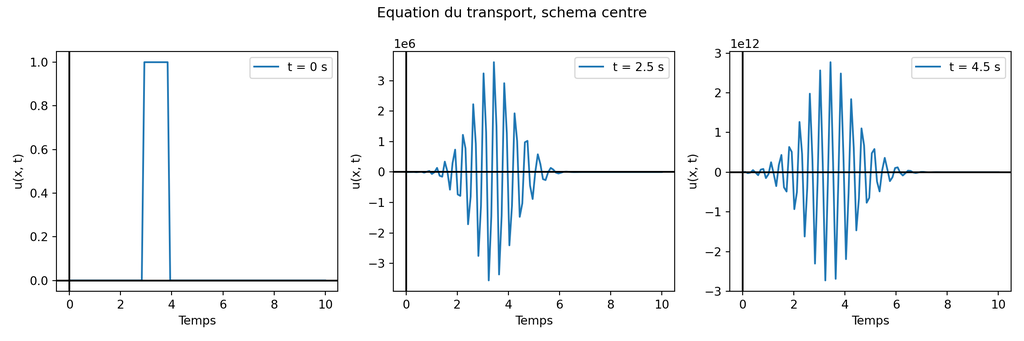

**Données** :

$L = 10 m ,\ a = 2 m/s , \ u_0(x) = 1\ pour\ 3 m \leq x \leq 4 m\ et\ 0 \ ailleurs.$

Nombre de Courant : $CFL = 0.8$.

# 2. Equation de Burgers

On considere maintenant l’equation de Burgers suivante:

**Données** :

$L = 6m ,\ u_0(x) = 0.4\ pour\ x < 2m \ et \ 0.1\ ailleurs.\ CFL = 0.8$.